# An Analysis of NC Removal on NC09

Tyler Richards - VoteShield

2019-03-04

## Background

In January of 2019, North Carolina removed 574,698 voters from their voters rolls, which amounts to 8% of all voters. It is customary for NC to remove voters from the rolls after an election, and there are spikes post 2016 (184,547 voters), 2014 (278,815 voters) but these are a third and half the size of the recent removal.

This is normally a cause for slight comment to North Carolina, as this is an abnormal number of voters to remove from the rolls. However, this situation is escalated because of the North Carolina’s 9th District. In an election decided by ~900 votes, a serious and unprecendented case of absentee ballot fraud was discovered, where a political operative for the campaign of Mark Harris broke election law by collecting and mailing voters’ ballots. There are some reports that the ballots were marked by the campaign. The operative is in jail, and Mark Harris has publicly stated that he will not run again.

As a result, on February 21st 2019 the election board did not certify the election, and ordered for a new election to take place.

questions we want answered: is the subpopulation significantly different from the total population? what is the voting history

## Demographic Breakdown:

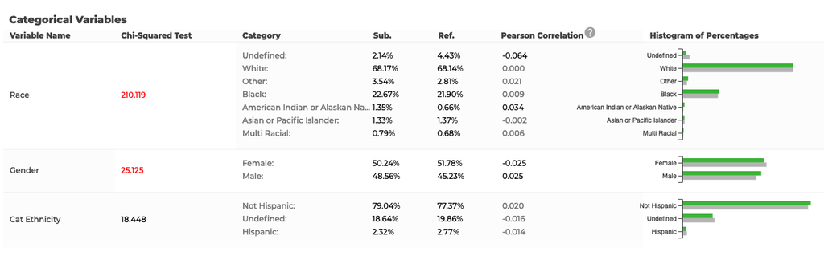

Currently, Voteshield does not have features to drill down at the district level so the rest of this will be an ad hoc analysis of the NC09 removed voters.

First, let’s look at the racial breakdown of the NC09 voters compared to the general population of NC09 voters. There is very little difference between the two, with slightly more black voters being removed compared to the general population. Other than that, there seems to be very little difference.

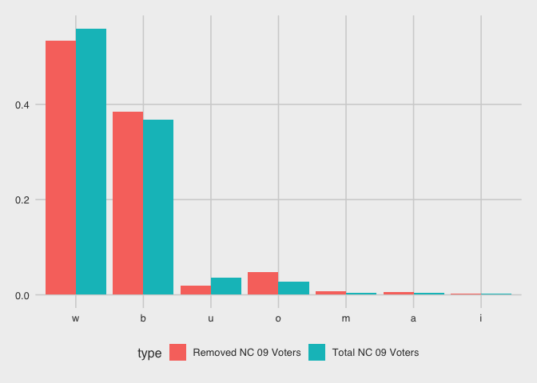

On age however, as expected, there is a large difference. The majority of the voters in the removed population are much younger, with a median of 44 years compared to the median of 51 for the total population.

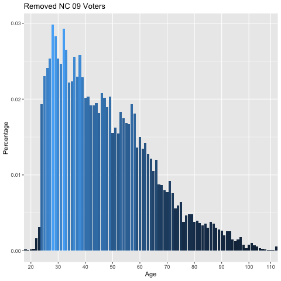

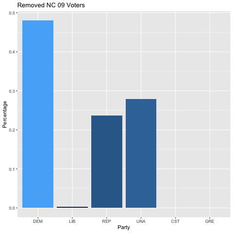

The North Carolina voter file contains a voter status reason description column that explains the reason behind a voter’s status, which is extremely useful here. Some of the options are armed forces, military, overseas citizen, or statuses based on voter verification. After a period of voter inactivity (usually lack of voting in two general elections), NC will send a confirmation to the voter via mail, and will either get a return mail in which case they will be a verified voter, or will not receive a confirmation. In that case, North Carolina will remove the voter from the voter rolls. This appears to be what happened with the removed voters in the 9th district, with roughly 80% of the removed population having this voter status reason description.

The last question a curious political scientist would have is about voter propensity. Are the removed population regular voters? This is largely a sanity check, as for the majority of the removed population a vote should have acted as a confirmation. Only 1403 of the removed population had any voter history in North Carolina, with 87% having no voting record at all. Of the 1403 who do, only 9 voted in the November 2018 election and none of those were removed for confirmation reasons.

This is reassuring, but the question remains: What will happen to the North Carolina voter who may have watched the last few weeks in North Carolina politics and, after not voting for the past few elections, turns up to the polls to vote but is now removed? With a full 8% of North Carolina’s voters removed, this situation seems increasingly likely.